# Proyecto

Andrea Maria Cabrera Rosito 999020185 y Alvaro Emmanuel Socop Perez 999020463

# Parte 1: Conociendo los datos

```r
# ------------------------------------------------
# ---------------- CARGA PAQUETES ----------------
# ------------------------------------------------

# Cargando los paquetes tidyverse, dplyr, ggplot 2. Se utiliza la función 'library' y como argumento el nombre de la librería:
library(tidyverse)
library(ggplot2)
library(dplyr)

# ----------------------------------------------------
# ---------------- LECTURA DE ARCHIVO ----------------
# ----------------------------------------------------


# Leyendo los archivos .csv que se compartieron, estos se guardaron en la misma carpeta donde se encuentra este script.
# Su utiliza la función read_csv y los datos son almacenados en dataframes.
paises_pib <- read_csv('paises_pib.csv')
proyectos_innovacion <- read_csv('proyectos_innovacion.csv')
# -------------------------------------------------------------
# ---------------- USO DE FUNCIONES HEAD Y STR ----------------
# -------------------------------------------------------------


# Obtención de más contexto con las funciones head y str:
# head para encabezados
head(paises_pib)
```

| pais | pib_millones |
| --- | --- |
| Guatemala | 331011 |
| Mexico | 464244 |
| Colombia | 178272 |
| Chile | 246179 |
| Peru | 736825 |
| Argentina | 522716 |

```r
head(proyectos_innovacion)
```

| id_proyecto | pais | area_tecnologica | presupuesto_usd | duracion_meses | investigadores | publicaciones | patentes | impacto | anio_inicio |
| --- | --- | --- | --- | --- | --- | --- | --- | --- | --- |
| 1 | Costa Rica | Inteligencia Artificial | 210775 | 7 | 16 | 10 | 0 | Medio | 2019 |
| 2 | Chile | Inteligencia Artificial | 1107913 | 25 | 10 | 4 | 0 | Bajo | 2023 |
| 3 | Paraguay | Energia Renovable | 620715 | 6 | 14 | 6 | 1 | Medio | 2024 |
| 4 | Panama | Nanotecnologia | 1613299 | 42 | 16 | 5 | 0 | Medio | 2019 |
| 5 | Peru | Salud Digital | 1422249 | 14 | 11 | 1 | 2 | Alto | 2019 |
| 6 | Costa Rica | Ciberseguridad | 414167 | 22 | 17 | 4 | 0 | Bajo | 2023 |

```r
# str para datos dentro del df
str(paises_pib)
```

```
## spc_tbl_ [12 × 2] (S3: spec_tbl_df/tbl_df/tbl/data.frame)
##  $ pais        : chr [1:12] "Guatemala" "Mexico" "Colombia" "Chile" ...
##  $ pib_millones: num [1:12] 331011 464244 178272 246179 736825 ...
##  - attr(*, "spec")=
##   .. cols(
##   ..   pais = col_character(),
##   ..   pib_millones = col_double()
##   .. )
##  - attr(*, "problems")=<externalptr>
```

```r
str(proyectos_innovacion)
```

```
## spc_tbl_ [400 × 10] (S3: spec_tbl_df/tbl_df/tbl/data.frame)
##  $ id_proyecto     : num [1:400] 1 2 3 4 5 6 7 8 9 10 ...
##  $ pais            : chr [1:400] "Costa Rica" "Chile" "Paraguay" "Panama" ...
##  $ area_tecnologica: chr [1:400] "Inteligencia Artificial" "Inteligencia Artificial" "Energia Renovable" "Nanotecnologia" ...
##  $ presupuesto_usd : num [1:400] 210775 1107913 620715 1613299 1422249 ...
##  $ duracion_meses  : num [1:400] 7 25 6 42 14 22 14 16 20 29 ...
##  $ investigadores  : num [1:400] 16 10 14 16 11 17 8 18 24 22 ...
##  $ publicaciones   : num [1:400] 10 4 6 5 1 4 4 8 3 8 ...
##  $ patentes        : num [1:400] 0 0 1 0 2 0 0 2 0 0 ...
##  $ impacto         : chr [1:400] "Medio" "Bajo" "Medio" "Medio" ...
##  $ anio_inicio     : num [1:400] 2019 2023 2024 2019 2019 ...
##  - attr(*, "spec")=
##   .. cols(
##   ..   id_proyecto = col_double(),
##   ..   pais = col_character(),
##   ..   area_tecnologica = col_character(),
##   ..   presupuesto_usd = col_double(),
##   ..   duracion_meses = col_double(),
##   ..   investigadores = col_double(),
##   ..   publicaciones = col_double(),
##   ..   patentes = col_double(),
##   ..   impacto = col_character(),
##   ..   anio_inicio = col_double()
##   .. )
##  - attr(*, "problems")=<externalptr>
```

# Parte 2: Creación y uso de listas:

```r
# ------------------------------------------------------------------
# ---------------- CONSTRUCCIÓN DE LISTA PRINCIPAL  ----------------
# ------------------------------------------------------------------

# Se contruye una lista que contenga:
# Df original, lista de paises, lista de áras tecnológicas, df con estadísticas inciales, subconjuntos de proyectos agrupados por área tecnológica.

# Primero se obtienen cada uno de los datos que se nos pide en la lista principal:
l_paises = paises_pib$pais # los paises en el df de paises_pib son los mismos que ya se encuentran en el df de proyectos innovación.
l_paises
```

```
##  [1] "Guatemala"  "Mexico"     "Colombia"   "Chile"      "Peru"
##  [6] "Argentina"  "Costa Rica" "Panama"     "Ecuador"    "Uruguay"
## [11] "Paraguay"   "Bolivia"
```

```r
l_areat = unique(proyectos_innovacion$area_tecnologica)
l_areat
```

```
## [1] "Inteligencia Artificial" "Energia Renovable"
## [3] "Nanotecnologia"          "Salud Digital"
## [5] "Ciberseguridad"          "Biotecnologia"
## [7] "Agrotecnologia"
```

```r
df_estadisticas_iniciales = proyectos_innovacion %>%
  summarise(
    total_presupuesto = sum(proyectos_innovacion$presupuesto_usd), # Total de presupuesto que se han tenido por todos los proyectos
    promedio_presupuesto = mean(proyectos_innovacion$presupuesto_usd), # se obtiene el promedio de presupuesto por proyecto
    promedio_duracion = mean(proyectos_innovacion$duracion_meses), # Promedio de meses que se ha tenido por todos los proyectos.
    promedio_publicaciones = mean(proyectos_innovacion$publicaciones), # se obtiene el promedio de publicaciones
    promedio_investigadores = mean(proyectos_innovacion$investigadores), # Se obtiene el promedio de investigadores
    total_publicaciones = sum(proyectos_innovacion$publicaciones), # Total de publicaciones que se han tenido al llevar a cabo los proyectos.
    total_patentes = sum(proyectos_innovacion$patentes) # Cuántas patentes se han logrado obtener en todos los proyectos.
  )
df_estadisticas_iniciales
```

| total_presupuesto | promedio_presupuesto | promedio_duracion | promedio_publicaciones | promedio_investigadores | total_publicaciones | total_patentes |
| --- | --- | --- | --- | --- | --- | --- |
| 394519326 | 986298.3 | 27.2025 | 5.065 | 12.67 | 2026 | 368 |

```r
sc_proy_area = split(proyectos_innovacion, proyectos_innovacion$area_tecnologica) # Se utliza 'split' en el df de proyectos de innovación,agrupando por el área tecnológica.

# Se crea la lista principal, definiendo el nombre de los encabezados:
listaPrincipal = list(df_original=proyectos_innovacion, paises=l_paises, areas_tecnologicas=l_areat, estadisticas_iniciales=df_estadisticas_iniciales, proyectos_area=sc_proy_area)
listaPrincipal
```

```
## $df_original
## # A tibble: 400 × 10
##    id_proyecto pais       area_tecnologica        presupuesto_usd duracion_meses
##          <dbl> <chr>      <chr>                             <dbl>          <dbl>
##  1           1 Costa Rica Inteligencia Artificial          210775              7
##  2           2 Chile      Inteligencia Artificial         1107913             25
##  3           3 Paraguay   Energia Renovable                620715              6
##  4           4 Panama     Nanotecnologia                  1613299             42
##  5           5 Peru       Salud Digital                   1422249             14
##  6           6 Costa Rica Ciberseguridad                   414167             22
##  7           7 Uruguay    Biotecnologia                   1445385             14
##  8           8 Colombia   Salud Digital                   1728651             16
##  9           9 Costa Rica Biotecnologia                    737281             20
## 10          10 Paraguay   Energia Renovable               1394027             29
## # ℹ 390 more rows
## # ℹ 5 more variables: investigadores <dbl>, publicaciones <dbl>,
## #   patentes <dbl>, impacto <chr>, anio_inicio <dbl>
##
## $paises
##  [1] "Guatemala"  "Mexico"     "Colombia"   "Chile"      "Peru"
##  [6] "Argentina"  "Costa Rica" "Panama"     "Ecuador"    "Uruguay"
## [11] "Paraguay"   "Bolivia"
##
## $areas_tecnologicas
## [1] "Inteligencia Artificial" "Energia Renovable"
## [3] "Nanotecnologia"          "Salud Digital"
## [5] "Ciberseguridad"          "Biotecnologia"
## [7] "Agrotecnologia"
##
## $estadisticas_iniciales
## # A tibble: 1 × 7
##   total_presupuesto promedio_presupuesto promedio_duracion
##               <dbl>                <dbl>             <dbl>
## 1         394519326              986298.              27.2
## # ℹ 4 more variables: promedio_publicaciones <dbl>,
## #   promedio_investigadores <dbl>, total_publicaciones <dbl>,
## #   total_patentes <dbl>
##
## $proyectos_area
## $proyectos_area$Agrotecnologia
```

[output cut: 109 more lines]

```
##    id_proyecto pais      area_tecnologica presupuesto_usd duracion_meses
##          <dbl> <chr>     <chr>                      <dbl>          <dbl>
##  1           5 Peru      Salud Digital            1422249             14
##  2           8 Colombia  Salud Digital            1728651             16
##  3          16 Panama    Salud Digital            1801541             19
##  4          26 Peru      Salud Digital            1650396             34
##  5          27 Guatemala Salud Digital            1263997             13
##  6          31 Bolivia   Salud Digital             448929             19
##  7          32 Ecuador   Salud Digital             630466             35
##  8          37 Bolivia   Salud Digital            1228049             24
##  9          48 Peru      Salud Digital            1723361             45
## 10          59 Peru      Salud Digital            1054208              7
## # ℹ 45 more rows
## # ℹ 5 more variables: investigadores <dbl>, publicaciones <dbl>,
## #   patentes <dbl>, impacto <chr>, anio_inicio <dbl>
```

```r
# -------------------------------------------------------
# ---------------- UTILIZACIÓN DE LAPPLY ----------------
# -------------------------------------------------------

# Se utiliza lapply que calcule para área tecnológica, en este caso se creó una función con el parámetro el dataframe. Este retornará los promedios:
obtencion_promedios = function(df){
  list(
    mean_presupuesto = mean(df$presupuesto_usd), # Promedio de presupuesto
    mean_publicaciones = mean(df$publicaciones), # Promedio de publicaciones
    mean_investigadores = mean(df$investigadores) # Promedio de investigadores
  )
}
                  #se indica que es por cada área
                  #tecnológica
resultado = lapply(listaPrincipal$proyectos_area, obtencion_promedios)
resultado
```

```
## $Agrotecnologia
## $Agrotecnologia$mean_presupuesto
## [1] 1064492
##
## $Agrotecnologia$mean_publicaciones
## [1] 5.25
##
## $Agrotecnologia$mean_investigadores
## [1] 13.17188
##
##
## $Biotecnologia
## $Biotecnologia$mean_presupuesto
## [1] 1060756
##
## $Biotecnologia$mean_publicaciones
## [1] 4.898305
##
## $Biotecnologia$mean_investigadores
## [1] 12.91525
##
##
## $Ciberseguridad
## $Ciberseguridad$mean_presupuesto
## [1] 949237.5
##
## $Ciberseguridad$mean_publicaciones
## [1] 4.788732
##
## $Ciberseguridad$mean_investigadores
## [1] 13.71831
##
##
## $`Energia Renovable`
## $`Energia Renovable`$mean_presupuesto
## [1] 845755.2
##
## $`Energia Renovable`$mean_publicaciones
## [1] 5.711111
##
```

[output cut: 20 more lines]

```
## [1] 5.166667
##
## $Nanotecnologia$mean_investigadores
## [1] 13.70833
##
##
## $`Salud Digital`
## $`Salud Digital`$mean_presupuesto
## [1] 1108867
##
## $`Salud Digital`$mean_publicaciones
## [1] 4.709091
##
## $`Salud Digital`$mean_investigadores
## [1] 10.98182
```

```r
# ------------------------------------------------------
# ---------------- LISTA DE INDICADORES ----------------
# ------------------------------------------------------

# Se crea la lista de indicadores donde cada elemento contenga:
# Area tecnológica, No. de proyectos, presupuesto promedio y productividad promedio.
# Se crea una función para el cálculo de los indicadores:
calcular_indicadores <- function(area, lista){
  df <- lista[[area]] # se obtiene por proyecto, el área.

  list(
    area_tecnologica = area, # obtención del área
    numero_proyectos = nrow(df), # cantidad de rows
    presupuesto_promedio = mean(df$presupuesto_usd), #se obtiene el promedio de presupuesto
    productividad_promedio = mean(df$publicaciones) # se obtiene el promedio de la productividad      (mean(df$publicaciones / df$investigadores))???
  )
}

# Se utiliza lapply:
indicadores = lapply(names(listaPrincipal$proyectos_area), function(area) {
  calcular_indicadores(area, listaPrincipal$proyectos_area)
})

indicadores
```

```
## [[1]]
## [[1]]$area_tecnologica
## [1] "Agrotecnologia"
##
## [[1]]$numero_proyectos
## [1] 64
##
## [[1]]$presupuesto_promedio
## [1] 1064492
##
## [[1]]$productividad_promedio
## [1] 5.25
##
##
## [[2]]
## [[2]]$area_tecnologica
## [1] "Biotecnologia"
##
## [[2]]$numero_proyectos
## [1] 59
##
## [[2]]$presupuesto_promedio
## [1] 1060756
##
## [[2]]$productividad_promedio
## [1] 4.898305
##
##
## [[3]]
## [[3]]$area_tecnologica
## [1] "Ciberseguridad"
##
## [[3]]$numero_proyectos
## [1] 71
##
## [[3]]$presupuesto_promedio
## [1] 949237.5
##
## [[3]]$productividad_promedio
## [1] 4.788732
```

[output cut: 41 more lines]

```
## [1] 5.166667
##
##
## [[7]]
## [[7]]$area_tecnologica
## [1] "Salud Digital"
##
## [[7]]$numero_proyectos
## [1] 55
##
## [[7]]$presupuesto_promedio
## [1] 1108867
##
## [[7]]$productividad_promedio
## [1] 4.709091
```

# Parte 3: Manipulación de datos con dplyr:

```r
# ----------------------------------------------------------
# ---------------- CREANDO NUEVAS VARIABLES ----------------
# ------------------- UTILIZANDO MUTATE --------------------
# ----------------------------------------------------------


# Crear nuevas variables utilizando mutate:
# Productividad (publicaciones/investigadores)
proyectos_innovacion = proyectos_innovacion %>%
  mutate(productividad = publicaciones/investigadores)

# intensidad_investigacion (investigadores/ duracion_meses)
proyectos_innovacion = proyectos_innovacion %>%
  mutate(intensidad_investigacion = investigadores/duracion_meses)

# indice_resultados [(publicaciones+2*patentes)/presupuesto_usd]
proyectos_innovacion = proyectos_innovacion %>%
  mutate(indice_resultados  = (publicaciones + 2*patentes)/presupuesto_usd)

# Revisión de las nuevas rariables:
proyectos_innovacion$productividad
```

```
##   [1] 0.62500000 0.40000000 0.42857143 0.31250000 0.09090909 0.23529412
##   [7] 0.50000000 0.44444444 0.12500000 0.36363636 0.30434783 0.37500000
##  [13] 0.33333333 0.18750000 0.27272727 0.50000000 0.60000000 0.35000000
##  [19] 0.17647059 0.33333333 0.26315789 0.04166667 0.31578947 0.19047619
##  [25] 0.37500000 1.25000000 0.36842105 0.63636364 0.62500000 0.50000000
##  [31] 0.46666667 0.50000000 0.76923077 0.28571429 2.33333333 1.25000000
##  [37] 1.16666667 0.66666667 0.55555556 0.16666667 0.25000000 0.76923077
##  [43] 0.50000000 0.25000000 0.16666667 1.00000000 0.08695652 0.57142857
##  [49] 0.31578947 3.00000000 0.23529412 0.42857143 0.27272727 0.30769231
##  [55] 1.33333333 0.20833333 0.50000000 0.27272727 2.33333333 0.33333333
##  [61] 0.35714286 0.07142857 0.36842105 1.75000000 0.37500000 0.46666667
##  [67] 0.09523810 0.22222222 0.22727273 0.46153846 0.17647059 0.61538462
##  [73] 0.25000000 0.63636364 0.25000000 0.23809524 1.16666667 2.50000000
##  [79] 0.16666667 1.75000000 0.28571429 0.26666667 0.15789474 1.60000000
##  [85] 0.26315789 0.50000000 0.29411765 1.50000000 0.18181818 0.13333333
```

[output cut: 52 more lines]

```r
proyectos_innovacion$intensidad_investigacion
```

```
##   [1] 2.28571429 0.40000000 2.33333333 0.38095238 0.78571429 0.77272727
##   [7] 0.57142857 1.12500000 1.20000000 0.75862069 0.53488372 0.20000000
##  [13] 0.42857143 0.44444444 2.20000000 0.42105263 0.62500000 1.42857143
##  [19] 0.43589744 0.52941176 0.47500000 0.60000000 3.16666667 0.46666667
##  [25] 0.29629630 0.11764706 1.46153846 0.68750000 0.17391304 0.42857143
##  [31] 0.78947368 0.11428571 0.32500000 0.53846154 0.07142857 0.40000000
##  [37] 0.25000000 0.63157895 0.29032258 2.66666667 0.80000000 0.27659574
##  [43] 0.26666667 0.69565217 0.40000000 0.38461538 0.52272727 0.31111111
##  [49] 1.00000000 0.05405405 0.39534884 0.36842105 0.39285714 0.65000000
##  [55] 0.07894737 0.80000000 0.18181818 0.28947368 0.42857143 1.26315789
##  [61] 0.31111111 0.31111111 0.43181818 0.36363636 0.72727273 1.87500000
##  [67] 1.75000000 1.38461538 0.46808511 0.65000000 0.50000000 0.34210526
##  [73] 0.45714286 0.25000000 0.25000000 0.51219512 0.17647059 0.04651163
##  [79] 0.47368421 0.09523810 0.43750000 0.39473684 2.11111111 0.18518519
##  [85] 2.71428571 0.40000000 1.70000000 0.13333333 0.57894737 0.34883721
```

[output cut: 52 more lines]

```r
proyectos_innovacion$indice_resultados
```

```
##   [1] 4.744396e-05 3.610392e-06 1.288836e-05 3.099240e-06 3.515559e-06
##   [6] 9.657940e-06 2.767429e-06 6.941829e-06 4.069005e-06 5.738770e-06
##  [11] 1.487554e-05 5.711526e-06 8.320783e-06 4.260439e-06 1.461022e-05
##  [16] 2.220321e-06 1.382699e-05 4.521195e-06 5.601499e-06 1.360811e-05
##  [21] 6.348029e-06 4.575017e-06 1.079758e-05 2.018148e-06 2.258288e-05
##  [26] 3.029576e-06 7.120270e-06 6.380436e-05 5.753797e-06 2.251049e-05
##  [31] 1.559267e-05 6.344513e-06 1.603348e-05 7.788829e-06 1.119502e-05
##  [36] 6.710277e-06 1.058590e-05 9.680083e-06 2.083306e-05 4.471407e-06
##  [41] 5.278490e-06 7.055719e-06 4.529218e-06 3.155719e-06 5.214643e-06
##  [46] 4.308900e-06 5.147210e-05 6.963138e-06 6.431592e-06 6.141903e-05
##  [51] 3.259043e-06 4.747335e-06 1.488197e-05 4.318955e-05 2.201896e-06
##  [56] 1.050493e-05 6.267353e-06 2.093227e-06 6.640056e-06 5.177195e-06
##  [61] 3.474704e-05 1.576438e-06 7.672814e-06 9.135105e-06 2.181732e-05
##  [66] 1.388779e-04 5.949743e-06 1.062014e-05 6.552684e-06 3.385393e-06
##  [71] 1.175764e-05 1.284007e-05 2.267836e-06 2.452999e-05 5.091831e-06
```

[output cut: 65 more lines]

```r
# ----------------------------------------------------------
# ------------------ UTILIZANDO GROUP_BY Y -----------------
# ------------------------ SUMMARIZE -----------------------
# ----------------------------------------------------------


# Utilizando group_by, summarize y generando:
# Preupuesto promedio por país y área tecnológica
presupuesto_pais_area = proyectos_innovacion %>%
  group_by(pais, area_tecnologica) %>% # Agrupando por país y área tecnológica.
  summarise(presupuesto_promedio = mean(presupuesto_usd)) # Se utiliza mean para obtención del promedio.
```

```
## `summarise()` has regrouped the output.
## ℹ Summaries were computed grouped by pais and area_tecnologica.
## ℹ Output is grouped by pais.
## ℹ Use `summarise(.groups = "drop_last")` to silence this message.
## ℹ Use `summarise(.by = c(pais, area_tecnologica))` for per-operation grouping
##   (`?dplyr::dplyr_by`) instead.
```

```r
# Número de proyectos por año
proyectos_anio = proyectos_innovacion %>%
  group_by(anio_inicio) %>% # agrupando por año
  summarise(numero_proyectios = n()) # se utiliza la función 'n' para obtener la cantidad.

# Productividad promedio por área tecnológica y nivel de impacto
productividad_area_impacto = proyectos_innovacion %>%
  group_by(area_tecnologica, impacto) %>% # agrupando por área tecnológica e impacto.
  summarise(productividad_promedio = mean(productividad)) # obteniendo promedio de productividad
```

```
## `summarise()` has regrouped the output.
## ℹ Summaries were computed grouped by area_tecnologica and impacto.
## ℹ Output is grouped by area_tecnologica.
## ℹ Use `summarise(.groups = "drop_last")` to silence this message.
## ℹ Use `summarise(.by = c(area_tecnologica, impacto))` for per-operation
##   grouping (`?dplyr::dplyr_by`) instead.
```

```r
presupuesto_pais_area
```

| pais | area_tecnologica | presupuesto_promedio |
| --- | --- | --- |
| Argentina | Agrotecnologia | 1337107.4 |
| Argentina | Biotecnologia | 595961.2 |
| Argentina | Ciberseguridad | 1488166.7 |
| Argentina | Energia Renovable | 645717.3 |
| Argentina | Inteligencia Artificial | 566304.5 |
| Argentina | Nanotecnologia | 726604.0 |
| Argentina | Salud Digital | 1212449.4 |
| Bolivia | Agrotecnologia | 988256.3 |
| Bolivia | Biotecnologia | 1267743.8 |
| Bolivia | Ciberseguridad | 1240532.8 |

[output cut: 74 more lines]

```r
proyectos_anio
```

| anio_inicio | numero_proyectios |
| --- | --- |
| 2019 | 60 |
| 2020 | 91 |
| 2021 | 50 |
| 2022 | 70 |
| 2023 | 67 |
| 2024 | 62 |

```r
productividad_area_impacto
```

| area_tecnologica | impacto | productividad_promedio |
| --- | --- | --- |
| Agrotecnologia | Alto | 0.5399594 |
| Agrotecnologia | Bajo | 0.4697111 |
| Agrotecnologia | Medio | 0.5835245 |
| Biotecnologia | Alto | 0.7248886 |
| Biotecnologia | Bajo | 0.7762490 |
| Biotecnologia | Medio | 0.3892281 |
| Ciberseguridad | Alto | 0.3551940 |
| Ciberseguridad | Bajo | 0.7340817 |
| Ciberseguridad | Medio | 0.4649415 |
| Energia Renovable | Alto | 0.9960966 |

[output cut: 11 more lines]

```r
# ------------------------------------------
# ---------------- RANKINKS ----------------
# -------------------------------------------

# Generación de Rankings:
# Top 10 proyectos con mayor eficiencia
top_10_proyectos = proyectos_innovacion %>%
  arrange(desc(indice_resultados)) %>% # Se reordena de manera descendinte el índice de resultados
  slice_head(n = 10) # para obtener los primeros 10, se utiliza la función de slice_head, indicando n=10.

# Top 5 países con mayor productividad promedio
top_5_paises = proyectos_innovacion %>%
  group_by(pais) %>% # Se agrupa por país
  summarise(productividad_promedio = mean(productividad)) %>% # summarize para obtención de promedio de productividad de los datos ya agrupados
  arrange(desc(productividad_promedio)) %>% # Se reordena de manera descendente
  slice_head(n = 5) # para obtener los primeros 5, se utiliza la función de slice_head, indicando n=5.

top_10_proyectos
```

| id_proyecto | pais | area_tecnologica | presupuesto_usd | duracion_meses | investigadores | publicaciones | patentes | impacto | anio_inicio | productividad | intensidad_investigacion | indice_resultados |
| --- | --- | --- | --- | --- | --- | --- | --- | --- | --- | --- | --- | --- |
| 66 | Panama | Energia Renovable | 50404 | 8 | 15 | 7 | 0 | Medio | 2021 | 0.4666667 | 1.8750000 | 1.388779e-04 |
| 214 | Mexico | Ciberseguridad | 101745 | 13 | 15 | 4 | 5 | Alto | 2020 | 0.2666667 | 1.1538462 | 1.375989e-04 |
| 275 | Guatemala | Biotecnologia | 51062 | 10 | 14 | 5 | 1 | Medio | 2019 | 0.3571429 | 1.4000000 | 1.370882e-04 |
| 123 | Costa Rica | Nanotecnologia | 51252 | 23 | 6 | 7 | 0 | Medio | 2023 | 1.1666667 | 0.2608696 | 1.365800e-04 |
| 400 | Panama | Ciberseguridad | 55287 | 17 | 7 | 7 | 0 | Bajo | 2021 | 1.0000000 | 0.4117647 | 1.266120e-04 |
| 302 | Colombia | Biotecnologia | 73275 | 39 | 16 | 8 | 0 | Medio | 2019 | 0.5000000 | 0.4102564 | 1.091778e-04 |
| 325 | Colombia | Energia Renovable | 122303 | 11 | 21 | 9 | 1 | Alto | 2023 | 0.4285714 | 1.9090909 | 8.994056e-05 |
| 132 | Peru | Salud Digital | 56949 | 13 | 18 | 5 | 0 | Medio | 2020 | 0.2777778 | 1.3846154 | 8.779785e-05 |
| 263 | Uruguay | Agrotecnologia | 168033 | 23 | 7 | 8 | 2 | Bajo | 2020 | 1.1428571 | 0.3043478 | 7.141454e-05 |
| 28 | Bolivia | Agrotecnologia | 172402 | 16 | 11 | 7 | 2 | Medio | 2020 | 0.6363636 | 0.6875000 | 6.380436e-05 |

```r
top_5_paises
```

| pais | productividad_promedio |
| --- | --- |
| Argentina | 0.8310927 |
| Bolivia | 0.6760199 |
| Costa Rica | 0.6536081 |
| Colombia | 0.6489343 |
| Ecuador | 0.6352710 |

# Parte 4: Integración de datasets:

```r
# ----------------------------------------------------------------------
# ---------------- INTEGRANDO DATASETS CON INNER_JOIN() ----------------
# ----------------------------------------------------------------------


# Utilizando el archivo paises_pib.csv:
# Integrando el dataset utilizando innerjoin
# Ya se tenían los datos cargados en un df, en la parte 1, entonces se utilizará la variable 'paises_pib'

df_paises_innovacion = inner_join(proyectos_innovacion, paises_pib, by = "pais")
df_paises_innovacion
```

| id_proyecto | pais | area_tecnologica | presupuesto_usd | duracion_meses | investigadores | publicaciones | patentes | impacto | anio_inicio | productividad | intensidad_investigacion | indice_resultados | pib_millones |
| --- | --- | --- | --- | --- | --- | --- | --- | --- | --- | --- | --- | --- | --- |
| 1 | Costa Rica | Inteligencia Artificial | 210775 | 7 | 16 | 10 | 0 | Medio | 2019 | 0.62500000 | 2.28571429 | 4.744396e-05 | 237508 |
| 2 | Chile | Inteligencia Artificial | 1107913 | 25 | 10 | 4 | 0 | Bajo | 2023 | 0.40000000 | 0.40000000 | 3.610392e-06 | 246179 |
| 3 | Paraguay | Energia Renovable | 620715 | 6 | 14 | 6 | 1 | Medio | 2024 | 0.42857143 | 2.33333333 | 1.288836e-05 | 402188 |
| 4 | Panama | Nanotecnologia | 1613299 | 42 | 16 | 5 | 0 | Medio | 2019 | 0.31250000 | 0.38095238 | 3.099240e-06 | 662710 |
| 5 | Peru | Salud Digital | 1422249 | 14 | 11 | 1 | 2 | Alto | 2019 | 0.09090909 | 0.78571429 | 3.515559e-06 | 736825 |
| 6 | Costa Rica | Ciberseguridad | 414167 | 22 | 17 | 4 | 0 | Bajo | 2023 | 0.23529412 | 0.77272727 | 9.657940e-06 | 237508 |
| 7 | Uruguay | Biotecnologia | 1445385 | 14 | 8 | 4 | 0 | Medio | 2019 | 0.50000000 | 0.57142857 | 2.767429e-06 | 239631 |
| 8 | Colombia | Salud Digital | 1728651 | 16 | 18 | 8 | 2 | Bajo | 2020 | 0.44444444 | 1.12500000 | 6.941829e-06 | 178272 |
| 9 | Costa Rica | Biotecnologia | 737281 | 20 | 24 | 3 | 0 | Medio | 2019 | 0.12500000 | 1.20000000 | 4.069005e-06 | 237508 |
| 10 | Paraguay | Energia Renovable | 1394027 | 29 | 22 | 8 | 0 | Medio | 2022 | 0.36363636 | 0.75862069 | 5.738770e-06 | 402188 |

[output cut: 390 more lines]

```r
# ----------------------------------------------------
# ---------------- NUEVOS INDICADORES ----------------
# ----------------------------------------------------

# Creando nuevos indicadores:
# Primero se hace la agrupación correspondiente (país y pib_millones)

agrupacion_datos = df_paises_innovacion %>%
  group_by(pais, pib_millones) %>%
  summarise(
    numero_proyectos = n(), # Se obtiene la cantidad de proyectos según la agrupación definida
    presupuesto_promedio = mean(presupuesto_usd) # Promedio del presupuesto
  )
```

```
## `summarise()` has regrouped the output.
## ℹ Summaries were computed grouped by pais and pib_millones.
## ℹ Output is grouped by pais.
## ℹ Use `summarise(.groups = "drop_last")` to silence this message.
## ℹ Use `summarise(.by = c(pais, pib_millones))` for per-operation grouping
##   (`?dplyr::dplyr_by`) instead.
```

```r
indicadores = agrupacion_datos = agrupacion_datos %>%
  mutate(
    presupuesto_relativo  = presupuesto_promedio /pib_millones
  )

# proyectos_por_millon_pib [numero_proyectos / pib_millones]
indicadores = agrupacion_datos = agrupacion_datos %>%
  mutate(
    proyectos_por_millon_pib = numero_proyectos/pib_millones
  )
indicadores$proyectos_por_millon_pib
```

```
##  [1] 5.356637e-05 7.438967e-04 1.299867e-04 2.187668e-04 1.473635e-04
##  [6] 8.647807e-05 1.268840e-04 6.031311e-05 5.583136e-05 6.961918e-05
## [11] 3.935806e-05 1.085002e-04
```

```r
# presupuesto_relativo [presupuesto_promedio / pib_millones]
indicadores = agrupacion_datos = agrupacion_datos %>%
  mutate(
    presupuesto_relativo  = presupuesto_promedio /pib_millones
  )

indicadores$presupuesto_relativo
```

```
##  [1]  1.908023 16.870897  4.893256  4.670129  4.241709  2.851766  2.614118
##  [8]  2.041059  1.475594  2.641363  1.295668  4.197793
```

```r
# Análisis
# Países con mayor intensidad de inversión e innovación
# Se busca qué proyectos poseen más pib, y obtención para saber a qué proyecto se le ha invertido más:
mayor_pib = indicadores %>% arrange(desc(proyectos_por_millon_pib))
mayor_pib
```

| pais | pib_millones | numero_proyectos | presupuesto_promedio | presupuesto_relativo | proyectos_por_millon_pib |
| --- | --- | --- | --- | --- | --- |
| Bolivia | 59148 | 44 | 997879.8 | 16.870897 | 7.438967e-04 |
| Colombia | 178272 | 39 | 832553.3 | 4.670129 | 2.187668e-04 |
| Costa Rica | 237508 | 35 | 1007439.9 | 4.241709 | 1.473635e-04 |
| Chile | 246179 | 32 | 1204616.9 | 4.893256 | 1.299867e-04 |
| Guatemala | 331011 | 42 | 865301.8 | 2.614118 | 1.268840e-04 |
| Uruguay | 239631 | 26 | 1005921.3 | 4.197793 | 1.085002e-04 |
| Ecuador | 370036 | 32 | 1055256.0 | 2.851766 | 8.647807e-05 |
| Paraguay | 402188 | 28 | 1062324.3 | 2.641363 | 6.961918e-05 |
| Mexico | 464244 | 28 | 947549.4 | 2.041059 | 6.031311e-05 |
| Panama | 662710 | 37 | 977890.6 | 1.475594 | 5.583136e-05 |

[output cut: 2 more lines]

```r
mayor_inversion = indicadores %>% arrange(desc(presupuesto_relativo))
mayor_inversion
```

| pais | pib_millones | numero_proyectos | presupuesto_promedio | presupuesto_relativo | proyectos_por_millon_pib |
| --- | --- | --- | --- | --- | --- |
| Bolivia | 59148 | 44 | 997879.8 | 16.870897 | 7.438967e-04 |
| Chile | 246179 | 32 | 1204616.9 | 4.893256 | 1.299867e-04 |
| Colombia | 178272 | 39 | 832553.3 | 4.670129 | 2.187668e-04 |
| Costa Rica | 237508 | 35 | 1007439.9 | 4.241709 | 1.473635e-04 |
| Uruguay | 239631 | 26 | 1005921.3 | 4.197793 | 1.085002e-04 |
| Ecuador | 370036 | 32 | 1055256.0 | 2.851766 | 8.647807e-05 |
| Paraguay | 402188 | 28 | 1062324.3 | 2.641363 | 6.961918e-05 |
| Guatemala | 331011 | 42 | 865301.8 | 2.614118 | 1.268840e-04 |
| Mexico | 464244 | 28 | 947549.4 | 2.041059 | 6.031311e-05 |
| Argentina | 522716 | 28 | 997354.4 | 1.908023 | 5.356637e-05 |

[output cut: 2 more lines]

```r
# Países con menor eficiencia relativa
eficiencias = df_paises_innovacion %>% # Obtención de dato de eficiencia
  group_by(pais, pib_millones) %>%
  summarize(
    eficiencia_promedio = mean(indice_resultados) # promedio de la eficiencia
  )
```

```
## `summarise()` has regrouped the output.
## ℹ Summaries were computed grouped by pais and pib_millones.
## ℹ Output is grouped by pais.
## ℹ Use `summarise(.groups = "drop_last")` to silence this message.
## ℹ Use `summarise(.by = c(pais, pib_millones))` for per-operation grouping
##   (`?dplyr::dplyr_by`) instead.
```

```r
menor_eficiencia_relativa = eficiencias %>%
  arrange(eficiencia_promedio) # Se ordena para tener el valor de menor a mayor, y así tener en cuenta qué países poseen la mejor eficiencia relativa.
menor_eficiencia_relativa
```

| pais | pib_millones | eficiencia_promedio |
| --- | --- | --- |
| Paraguay | 402188 | 8.992032e-06 |
| Chile | 246179 | 9.906315e-06 |
| Ecuador | 370036 | 9.921098e-06 |
| Argentina | 522716 | 1.071351e-05 |
| Uruguay | 239631 | 1.073273e-05 |
| Peru | 736825 | 1.249295e-05 |
| Bolivia | 59148 | 1.274080e-05 |
| Costa Rica | 237508 | 1.502580e-05 |
| Guatemala | 331011 | 1.522702e-05 |
| Mexico | 464244 | 1.685133e-05 |

[output cut: 2 more lines]

# Parte 5: Lógica condicional

```r
# ------------------------------------------------------------
# ---------------- CLASIFICACIÓN DE PROYECTOS ----------------
# ------------------------------------------------------------

# Implementando clasificación de proyectos utilizando reglas múltiples.
# Creando columna 'categoria_proyecto' basada en productividad, presupuesto e impacto. Implementado en if, else if y else.

clasificar_proyecto = function(prod, pres, imp){
  # Se hace la primera confición, si el impacto es alto y la productividad también:
  if(imp == "Alto" & prod > 1){ # Ya existe la categoría de impacto, se tomará la productividad alta si es mayor a 1.
    return("Proyecto Estratégico")
  }
   # Si posee un gran presupuesto, pero la productividad es menos de 0.5 (mal rendimiento), porque se le está invirtiendo
  # mucho dinero pero los resultados no se ven positivos.
  else if (pres > 1000000 & prod < 0.5){
    return("Riesgo de Ineficiencia")
  }

  # Productividad media (está entre 0.5 y 1 y el presupuesto invertido no supera el millón para considerarse riesgo de ineficiencia.)
  else if (prod >=0.5 & prod <=1 & pres < 1000000){
    return("Proyecto estándar")
  }

  # Resto:
  else {
    return("Proyecto Emergente")
  }
}

proyectos_innovacion$categoria_proyecto <- mapply( # utilizando mapply para que se aplique fila por fila.
  clasificar_proyecto, # función
  proyectos_innovacion$productividad,
  proyectos_innovacion$presupuesto_usd,
  proyectos_innovacion$impacto
)
#Resultado:
proyectos_innovacion$categoria_proyecto
```

```
##   [1] "Proyecto estándar"      "Riesgo de Ineficiencia" "Proyecto Emergente"
##   [4] "Riesgo de Ineficiencia" "Riesgo de Ineficiencia" "Proyecto Emergente"
##   [7] "Proyecto Emergente"     "Riesgo de Ineficiencia" "Proyecto Emergente"
##  [10] "Riesgo de Ineficiencia" "Proyecto Emergente"     "Riesgo de Ineficiencia"
##  [13] "Proyecto Emergente"     "Riesgo de Ineficiencia" "Proyecto Emergente"
##  [16] "Proyecto Emergente"     "Proyecto estándar"      "Riesgo de Ineficiencia"
##  [19] "Riesgo de Ineficiencia" "Proyecto Emergente"     "Riesgo de Ineficiencia"
##  [22] "Riesgo de Ineficiencia" "Proyecto Emergente"     "Riesgo de Ineficiencia"
##  [25] "Proyecto Emergente"     "Proyecto Emergente"     "Riesgo de Ineficiencia"
##  [28] "Proyecto estándar"      "Proyecto Emergente"     "Proyecto estándar"
##  [31] "Proyecto Emergente"     "Proyecto estándar"      "Proyecto estándar"
##  [34] "Proyecto Emergente"     "Proyecto Emergente"     "Proyecto Emergente"
##  [37] "Proyecto Emergente"     "Proyecto Emergente"     "Proyecto estándar"
##  [40] "Proyecto Emergente"     "Riesgo de Ineficiencia" "Proyecto Emergente"
##  [43] "Proyecto Emergente"     "Riesgo de Ineficiencia" "Proyecto Emergente"
```

[output cut: 119 more lines]

# Parte 6: Programación con ciclos

```r
# ------------------------------------------------------------
# ---------------- PROGRAMACIÓN CON CICLOS -------------------
# ------------------------------------------------------------

# ============================================================
# ========== CICLO FOR - GENERACIÓN DE INDICADORES ===========
# ============================================================

# Se genera un dataframe dinámicamente recorriendo cada país y calculando:
# - Número de proyectos
# - Presupuesto total
# - Promedio de publicaciones
# - Índice de eficiencia promedio
# Primero se define la eficiencia del proyecto:
proyectos_innovacion <- proyectos_innovacion %>%
  mutate(eficiencia = (publicaciones + patentes) / presupuesto_usd)

# Se obtiene la lista única de países:
lista_paises <- unique(proyectos_innovacion$pais)

# Se crea un dataframe vacío donde se almacenarán los resultados:
indicadores_pais <- data.frame(
  pais = character(),
  numero_proyectos = numeric(),
  presupuesto_total = numeric(),
  promedio_publicaciones = numeric(),
  eficiencia_promedio = numeric(),
  stringsAsFactors = FALSE
)

# Ciclo FOR para recorrer cada país:
for (p in lista_paises) {

  # Se filtran los proyectos del país actual:
  df_pais <- proyectos_innovacion %>%
    filter(pais == p)

  # Se calculan los indicadores:
  numero_proyectos <- nrow(df_pais)
  presupuesto_total <- sum(df_pais$presupuesto_usd)
  promedio_publicaciones <- mean(df_pais$publicaciones)
  eficiencia_promedio <- mean(df_pais$eficiencia)

  # Se agregan los resultados al dataframe dinámicamente:
  indicadores_pais <- rbind(
    indicadores_pais,
    data.frame(
      pais = p,
      numero_proyectos = numero_proyectos,
      presupuesto_total = presupuesto_total,
      promedio_publicaciones = promedio_publicaciones,
      eficiencia_promedio = eficiencia_promedio
    )
  )
}

# Mostrando resultados:
indicadores_pais
```

| pais | numero_proyectos | presupuesto_total | promedio_publicaciones | eficiencia_promedio |
| --- | --- | --- | --- | --- |
| Costa Rica | 35 | 35260397 | 5.028571 | 1.366013e-05 |
| Chile | 32 | 38547742 | 4.875000 | 8.663492e-06 |
| Paraguay | 28 | 29745081 | 4.714286 | 7.999389e-06 |
| Panama | 37 | 36181954 | 5.756757 | 1.618713e-05 |
| Peru | 29 | 27685733 | 4.793103 | 1.145801e-05 |
| Uruguay | 26 | 26153955 | 4.307692 | 9.586294e-06 |
| Colombia | 39 | 32469578 | 5.307692 | 1.653330e-05 |
| Argentina | 28 | 27925922 | 5.821429 | 9.466890e-06 |
| Mexico | 28 | 26531383 | 5.250000 | 1.338068e-05 |
| Bolivia | 44 | 43906712 | 5.204545 | 1.083629e-05 |

[output cut: 2 more lines]

```r
# ============================================================
# ====== CICLO WHILE - BÚSQUEDA DE PROYECTOS SOBRESALIENTES ==
# ============================================================


# Se calcula el umbral como:
# media + 2 * desviación estándar de la eficiencia

media_eficiencia <- mean(proyectos_innovacion$eficiencia)
desviacion_eficiencia <- sd(proyectos_innovacion$eficiencia)
umbral_eficiencia <- media_eficiencia + 2 * desviacion_eficiencia

umbral_eficiencia
```

```
## [1] 4.773478e-05
```

```r
# Se creará un vector para almacenar los identificadores
# de proyectos sobresalientes.

proyectos_sobresalientes <- c()

# Índice inicial
i <- 1

# Ciclo WHILE para recorrer el dataset
while (i <= nrow(proyectos_innovacion)) {

  if (proyectos_innovacion$eficiencia[i] > umbral_eficiencia) {
    proyectos_sobresalientes <- c(proyectos_sobresalientes, proyectos_innovacion$id_proyecto[i])
  }

  i <- i + 1
}

# Resultado:
proyectos_sobresalientes
```

```
##  [1]  28  50  66 123 132 200 214 220 231 247 263 275 302 325 328 333 400
```

```r
# el detalle de esos proyectos:
detalle_sobresalientes <- proyectos_innovacion %>%
  filter(id_proyecto %in% proyectos_sobresalientes)

detalle_sobresalientes
```

| id_proyecto | pais | area_tecnologica | presupuesto_usd | duracion_meses | investigadores | publicaciones | patentes | impacto | anio_inicio | productividad | intensidad_investigacion | indice_resultados | categoria_proyecto | eficiencia |
| --- | --- | --- | --- | --- | --- | --- | --- | --- | --- | --- | --- | --- | --- | --- |
| 28 | Bolivia | Agrotecnologia | 172402 | 16 | 11 | 7 | 2 | Medio | 2020 | 0.6363636 | 0.68750000 | 6.380436e-05 | Proyecto estándar | 5.220357e-05 |
| 50 | Costa Rica | Energia Renovable | 162816 | 37 | 2 | 6 | 2 | Bajo | 2021 | 3.0000000 | 0.05405405 | 6.141903e-05 | Proyecto Emergente | 4.913522e-05 |
| 66 | Panama | Energia Renovable | 50404 | 8 | 15 | 7 | 0 | Medio | 2021 | 0.4666667 | 1.87500000 | 1.388779e-04 | Proyecto Emergente | 1.388779e-04 |
| 123 | Costa Rica | Nanotecnologia | 51252 | 23 | 6 | 7 | 0 | Medio | 2023 | 1.1666667 | 0.26086957 | 1.365800e-04 | Proyecto Emergente | 1.365800e-04 |
| 132 | Peru | Salud Digital | 56949 | 13 | 18 | 5 | 0 | Medio | 2020 | 0.2777778 | 1.38461538 | 8.779785e-05 | Proyecto Emergente | 8.779785e-05 |
| 200 | Uruguay | Agrotecnologia | 107108 | 34 | 8 | 6 | 0 | Bajo | 2022 | 0.7500000 | 0.23529412 | 5.601822e-05 | Proyecto estándar | 5.601822e-05 |
| 214 | Mexico | Ciberseguridad | 101745 | 13 | 15 | 4 | 5 | Alto | 2020 | 0.2666667 | 1.15384615 | 1.375989e-04 | Proyecto Emergente | 8.845644e-05 |
| 220 | Guatemala | Biotecnologia | 73321 | 15 | 15 | 4 | 0 | Alto | 2019 | 0.2666667 | 1.00000000 | 5.455463e-05 | Proyecto Emergente | 5.455463e-05 |
| 231 | Colombia | Inteligencia Artificial | 145257 | 8 | 8 | 7 | 0 | Bajo | 2023 | 0.8750000 | 1.00000000 | 4.819045e-05 | Proyecto estándar | 4.819045e-05 |
| 247 | Chile | Ciberseguridad | 117661 | 9 | 11 | 5 | 1 | Bajo | 2023 | 0.4545455 | 1.22222222 | 5.949295e-05 | Proyecto Emergente | 5.099396e-05 |

[output cut: 7 more lines]

# Parte 7: Desarrollo de funciones analíticas

```r
# ------------------------------------------------------------
# ------------- DESARROLLO DE FUNCIONES ANALÍTICAS -----------
# ------------------------------------------------------------

# ============================================================
# ============ FUNCIÓN 1: ÍNDICE DE EFICIENCIA ===============
# ============================================================

# La función calculará:
# eficiencia = (publicaciones + patentes) / presupuesto

calcular_eficiencia <- function(publicaciones, patentes, presupuesto) {
  eficiencia <- (publicaciones + patentes) / presupuesto
  return(eficiencia)
}

# Aplicamos:
proyectos_innovacion$eficiencia_funcion <- mapply(
  calcular_eficiencia,
  proyectos_innovacion$publicaciones,
  proyectos_innovacion$patentes,
  proyectos_innovacion$presupuesto_usd
)

proyectos_innovacion$eficiencia_funcion
```

```
##   [1] 4.744396e-05 3.610392e-06 1.127732e-05 3.099240e-06 2.109335e-06
##   [6] 9.657940e-06 2.767429e-06 5.784858e-06 4.069005e-06 5.738770e-06
##  [11] 1.487554e-05 4.079661e-06 7.132100e-06 3.043171e-06 1.278394e-05
##  [16] 2.220321e-06 1.382699e-05 4.018840e-06 3.564590e-06 1.088649e-05
##  [21] 4.937356e-06 2.745010e-06 9.447879e-06 2.018148e-06 2.258288e-05
##  [26] 3.029576e-06 6.329129e-06 5.220357e-05 4.931826e-06 2.046408e-05
##  [31] 1.559267e-05 4.758385e-06 1.603348e-05 7.788829e-06 1.119502e-05
##  [36] 5.751666e-06 8.142998e-06 8.712075e-06 1.515131e-05 4.471407e-06
##  [41] 4.618679e-06 7.055719e-06 3.774348e-06 3.155719e-06 5.214643e-06
##  [46] 4.308900e-06 3.860408e-05 5.802615e-06 4.823694e-06 4.913522e-05
##  [51] 3.259043e-06 4.153918e-06 1.190558e-05 3.239216e-05 2.201896e-06
##  [56] 8.170497e-06 6.267353e-06 2.093227e-06 6.640056e-06 4.659475e-06
##  [61] 2.978318e-05 1.050958e-06 7.672814e-06 7.474177e-06 1.558380e-05
##  [66] 1.388779e-04 3.966495e-06 7.965102e-06 5.096532e-06 3.385393e-06
##  [71] 7.838424e-06 1.070006e-05 2.267836e-06 2.452999e-05 5.091831e-06
```

[output cut: 65 more lines]

```r
# ============================================================
# ===== FUNCIÓN 2: IDENTIFICAR PROYECTOS CON ALTO IMPACTO ====
# ============================================================

# Esta función recibe un dataframe y devuelve únicamente los proyectos con impacto alto, asignándolos como categoría estratégica.

identificar_alto_impacto <- function(df) {
  df_alto <- df %>%
    filter(impacto == "Alto") %>%
    mutate(categoria_estrategica = "Estratégico")

  return(df_alto)
}

proyectos_alto_impacto <- identificar_alto_impacto(proyectos_innovacion)
proyectos_alto_impacto
```

| id_proyecto | pais | area_tecnologica | presupuesto_usd | duracion_meses | investigadores | publicaciones | patentes | impacto | anio_inicio | productividad | intensidad_investigacion | indice_resultados | categoria_proyecto | eficiencia | eficiencia_funcion | categoria_estrategica |
| --- | --- | --- | --- | --- | --- | --- | --- | --- | --- | --- | --- | --- | --- | --- | --- | --- |
| 5 | Peru | Salud Digital | 1422249 | 14 | 11 | 1 | 2 | Alto | 2019 | 0.09090909 | 0.78571429 | 3.515559e-06 | Riesgo de Ineficiencia | 2.109335e-06 | 2.109335e-06 | Estratégico |
| 11 | Paraguay | Biotecnologia | 470571 | 43 | 23 | 7 | 0 | Alto | 2024 | 0.30434783 | 0.53488372 | 1.487554e-05 | Proyecto Emergente | 1.487554e-05 | 1.487554e-05 | Estratégico |
| 31 | Bolivia | Salud Digital | 448929 | 19 | 15 | 7 | 0 | Alto | 2023 | 0.46666667 | 0.78947368 | 1.559267e-05 | Proyecto Emergente | 1.559267e-05 | 1.559267e-05 | Estratégico |
| 44 | Colombia | Inteligencia Artificial | 1267540 | 23 | 16 | 4 | 0 | Alto | 2022 | 0.25000000 | 0.69565217 | 3.155719e-06 | Riesgo de Ineficiencia | 3.155719e-06 | 3.155719e-06 | Estratégico |
| 54 | Bolivia | Ciberseguridad | 185230 | 20 | 13 | 4 | 2 | Alto | 2019 | 0.30769231 | 0.65000000 | 4.318955e-05 | Proyecto Emergente | 3.239216e-05 | 3.239216e-05 | Estratégico |
| 62 | Bolivia | Ciberseguridad | 1903025 | 45 | 14 | 1 | 1 | Alto | 2021 | 0.07142857 | 0.31111111 | 1.576438e-06 | Riesgo de Ineficiencia | 1.050958e-06 | 1.050958e-06 | Estratégico |
| 63 | Bolivia | Agrotecnologia | 912312 | 44 | 19 | 7 | 0 | Alto | 2020 | 0.36842105 | 0.43181818 | 7.672814e-06 | Proyecto Emergente | 7.672814e-06 | 7.672814e-06 | Estratégico |
| 64 | Costa Rica | Nanotecnologia | 1204146 | 11 | 4 | 7 | 2 | Alto | 2019 | 1.75000000 | 0.36363636 | 9.135105e-06 | Proyecto Estratégico | 7.474177e-06 | 7.474177e-06 | Estratégico |
| 74 | Argentina | Energia Renovable | 285365 | 44 | 11 | 7 | 0 | Alto | 2019 | 0.63636364 | 0.25000000 | 2.452999e-05 | Proyecto estándar | 2.452999e-05 | 2.452999e-05 | Estratégico |
| 79 | Mexico | Biotecnologia | 250244 | 38 | 18 | 3 | 2 | Alto | 2023 | 0.16666667 | 0.47368421 | 2.797270e-05 | Proyecto Emergente | 1.998050e-05 | 1.998050e-05 | Estratégico |

[output cut: 74 more lines]

```r
# ============================================================
# ===== FUNCIÓN 3: RESUMEN ESTADÍSTICO DE UNA VARIABLE =======
# ============================================================

# La función devuelve media, mediana, desviación estándar y percentiles

resumen_estadistico <- function(variable) {
  resumen <- list(
    media = mean(variable),
    mediana = median(variable),
    desviacion_estandar = sd(variable),
    percentil_25 = quantile(variable, 0.25),
    percentil_50 = quantile(variable, 0.50),
    percentil_75 = quantile(variable, 0.75)
  )

  return(resumen)
}

# Se usa lapply sobre varias variables numéricas del dataframe:
variables_numericas <- list(
  presupuesto_usd = proyectos_innovacion$presupuesto_usd,
  publicaciones = proyectos_innovacion$publicaciones,
  investigadores = proyectos_innovacion$investigadores,
  eficiencia = proyectos_innovacion$eficiencia_funcion
)

resumenes_variables <- lapply(variables_numericas, resumen_estadistico)
resumenes_variables
```

```
## $presupuesto_usd
## $presupuesto_usd$media
## [1] 986298.3
##
## $presupuesto_usd$mediana
## [1] 943577
##
## $presupuesto_usd$desviacion_estandar
## [1] 553683.2
##
## $presupuesto_usd$percentil_25
##      25%
## 525582.8
##
## $presupuesto_usd$percentil_50
##    50%
## 943577
##
## $presupuesto_usd$percentil_75
##     75%
## 1434766
##
##
## $publicaciones
## $publicaciones$media
## [1] 5.065
##
## $publicaciones$mediana
## [1] 5
##
## $publicaciones$desviacion_estandar
## [1] 2.260209
##
## $publicaciones$percentil_25
## 25%
##   3
##
## $publicaciones$percentil_50
## 50%
##   5
```

[output cut: 35 more lines]

```
##
## $eficiencia$desviacion_estandar
## [1] 1.794123e-05
##
## $eficiencia$percentil_25
##          25%
## 3.889353e-06
##
## $eficiencia$percentil_50
##         50%
## 6.33053e-06
##
## $eficiencia$percentil_75
##          75%
## 1.132885e-05
```

# Parte 8: Visualización

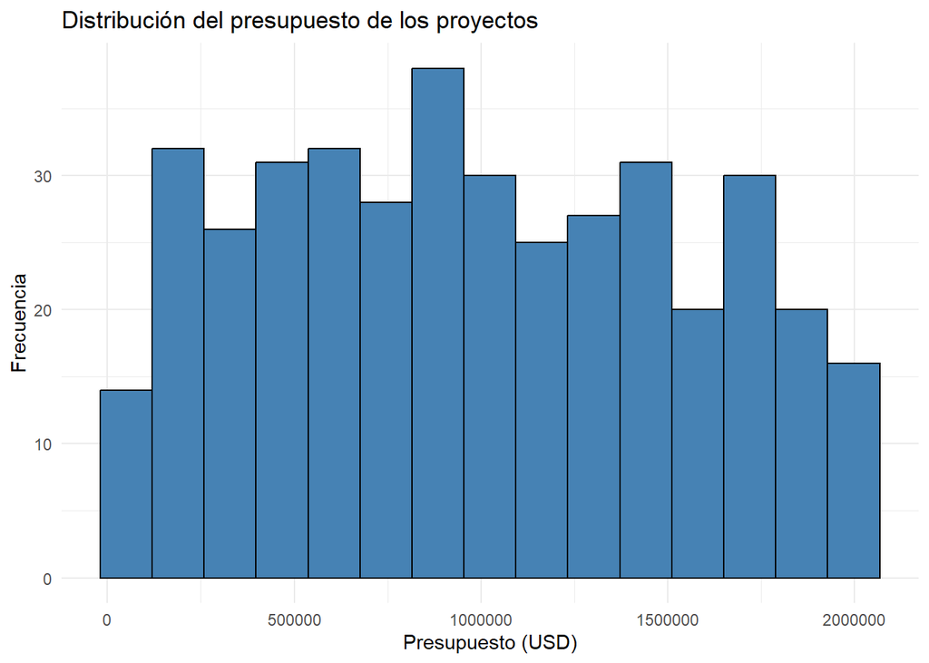

```r
# ------------------------------------------------------------
# -------------------- VISUALIZACIONES -----------------------
# ------------------------------------------------------------

# ============================================================
# ====================== HISTOGRAMA ===========================
# ============================================================

# Distribución de presupuesto_usd

ggplot(proyectos_innovacion, aes(x = presupuesto_usd)) +
  geom_histogram(bins = 15, fill = "steelblue", color = "black") +
  labs(
    title = "Distribución del presupuesto de los proyectos",
    x = "Presupuesto (USD)",
    y = "Frecuencia"
  ) +
  theme_minimal()
```

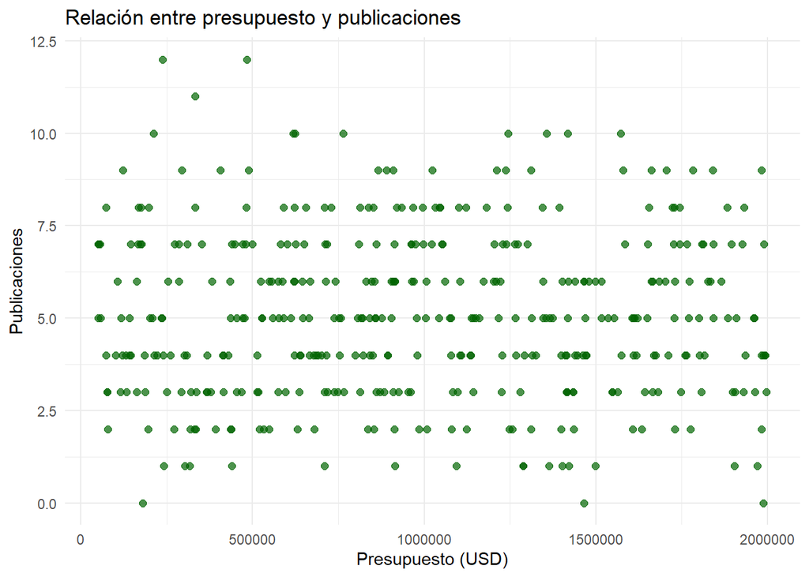

```r
# ============================================================
# ================= GRÁFICA DE DISPERSIÓN ====================
# ============================================================

# Relación entre presupuesto y publicaciones

ggplot(proyectos_innovacion, aes(x = presupuesto_usd, y = publicaciones)) +
  geom_point(color = "darkgreen", size = 2, alpha = 0.7) +
  labs(
    title = "Relación entre presupuesto y publicaciones",
    x = "Presupuesto (USD)",
    y = "Publicaciones"
  ) +
  theme_minimal()
```

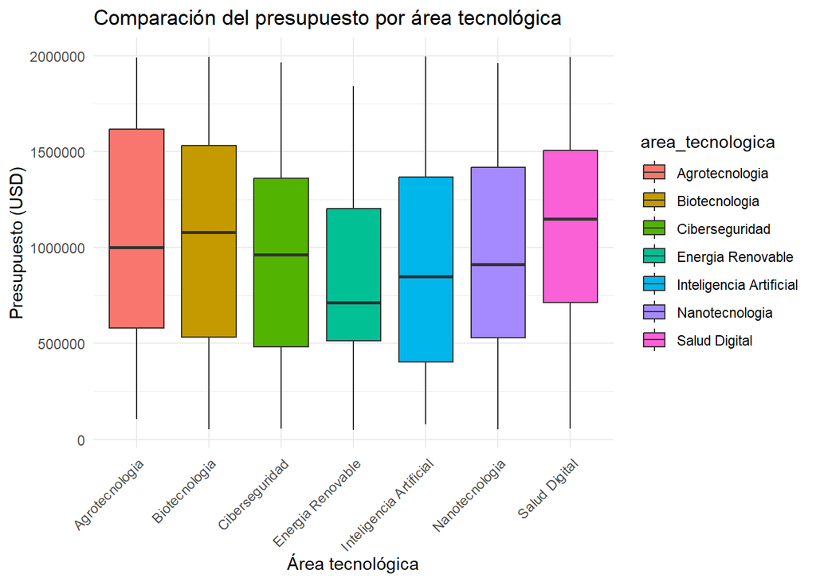

```r
# ============================================================
# ======================== BOXPLOT ============================
# ============================================================

# Comparar presupuesto por área tecnológica

ggplot(proyectos_innovacion, aes(x = area_tecnologica, y = presupuesto_usd, fill = area_tecnologica)) +
  geom_boxplot() +
  labs(
    title = "Comparación del presupuesto por área tecnológica",
    x = "Área tecnológica",
    y = "Presupuesto (USD)"
  ) +
  theme_minimal() +
  theme(axis.text.x = element_text(angle = 45, hjust = 1))
```

# Parte 9: Análisis e interpretación

### Análisis general de resultados

#### 1. ¿Qué áreas tecnológicas reciben mayor financiamiento?

R// Al analizar el presupuesto promedio por área tecnológica. Salud Digital destaca como una de las áreas con presupuestos promedio más altos en varios países (ej. Chile con USD 1,660,102, Costa Rica con USD 1,564,216, Uruguay con USD 1,293,795 y México con USD 1,272,869), reflejando una clara priorización del sector salud impulsada probablemente despues de la pandemia. Le siguen áreas como Biotecnología (Chile USD 1,433,524, Ecuador USD 1,395,951) y Ciberseguridad (Argentina USD 1,488,167), que también concentran montos considerables. En contraste, áreas como Inteligencia Artificial y Energía Renovable presentan presupuestos más variables: por ejemplo, Energía Renovable en Ecuador apenas alcanza USD 120,390, mientras que en Perú llega a USD 1,744,329. Esto sugiere que los presupuestos no se distribuyen de forma homogénea, sino que dependen de las prioridades estratégicas de cada país.

#### 2. ¿Existe relación entre presupuesto y resultados?

R// Al observar la gráfica de dispersión entre presupuesto y publicaciones, no se identifica una relación lineal clara entre ambas variables. Los proyectos con mayor presupuesto no necesariamente generan más publicaciones, lo que se confirma al revisar el Top 10 de proyectos con mayor índice de eficiencia: paradójicamente, los proyectos más eficientes son aquellos con presupuestos relativamente bajos (entre USD 50,000 y USD 170,000), no los más costosos. Por ejemplo, el proyecto #66 (Panamá, Energía Renovable) con apenas USD 50,404 logró un índice de resultados de 1.388779e-04 el más alto de todo el dataset. Esto sugiere que mayor inversión no garantiza mejores resultados, y que la eficiencia depende más de la gestión, capacidad del equipo y enfoque del proyecto que del monto invertido. Este hallazgo se puede hacer notar mas el caso de Chile, que aparece simultáneamente en los países con mayor inversión relativa y entre los de menor eficiencia relativa.

#### 3. ¿Qué países presentan mayor productividad?

R// El análisis del Top 5 revela el siguiente ranking:

Argentina — 0.831 publicaciones por investigador Bolivia — 0.676 Costa Rica — 0.654 Colombia — 0.649 Ecuador — 0.635

Argentina lidera de manera destacada, con una productividad considerablemente superior al resto, lo que indica que sus equipos generan más resultados académicos por cada investigador involucrado. Es raro que Bolivia, que también lideró en intensidad de inversión relativa al PIB, aparezca segundo en productividad, mostrando que su esfuerzo inversor sí se traduce en producción científica. Sin embargo, países con economías más grandes como Perú y México no aparecen en el top, lo que confirma que el tamaño económico no es determinante de la productividad investigativa.

#### 4. ¿Se identifican proyectos atípicos?

R// Sí. Aplicando la regla media + 2 desviaciones estándar sobre el índice de eficiencia, se obtuvo un umbral de 4.77e-05, identificándose 17 proyectos sobresalientes (IDs: 28, 50, 66, 123, 132, 200, 214, 220, 231, 247, 263, 275, 302, 325, 328, 333, 400). Estos representan el 4.25% del total de 400 proyectos, lo que confirma su carácter atípico. Geográficamente están distribuidos entre varios países (Panamá, México, Guatemala, Costa Rica, Colombia, Perú, Uruguay, Bolivia), y abarcan áreas como Energía Renovable, Ciberseguridad, Biotecnología, Nanotecnología y Salud Digital, lo cual sugiere que la excelencia no se concentra en un país o sector específico.

#### 5. Interpretación final

R// El análisis de los 400 proyectos de innovación en 12 países permite extraer varias conclusiones:

Los recursos económicos no determinan los resultados de innovación. Países pequeños como Bolivia destinan proporcionalmente más recursos al PIB en innovación (16.87 de presupuesto relativo), pero países como Argentina logran mayor productividad investigativa con menor inversión relativa. Esto refuerza que la calidad de la gestión, el talento humano y el enfoque estratégico pesan más que el monto invertido.

Existe un fenómeno de “inversión sin retorno” en países como Chile y Paraguay, que destinan recursos significativos a innovación pero presentan baja eficiencia relativa (Paraguay con 8.99e-06 y Chile con 9.9e-06 menor_eficiencia_relativa). Esto sugiere oportunidades para revisar sus modelos de gestión de proyectos.

La excelencia es excepcional pero replicable. Solo el 4.25% de los proyectos califica como sobresaliente, pero su distribución geográfica y temática diversa indica que cualquier país y cualquier área tecnológica puede generar proyectos de alto impacto si se implementan buenas prácticas de gestión.

Para mejorar los resultados de innovación en la región no basta con aumentar la inversión, sino que es fundamental fortalecer la gestión de proyectos, fomentar la colaboración entre investigadores y aprender de los proyectos sobresalientes para replicar sus prácticas.